title: “Portfolio 5: Creating A Random Dataset” author: “Ryan Wheat” date: “2023-04-16” output: html_document —

```r
library(tidyr)
library(tidyverse)
library(dplyr)
```

Background: I need to create a dataframe for my 312 PSYC METHODS students to analyze.

The Topic: Previous research has found that wearing a backpack depletes mental resources such that objects seem further away when wearing one, than without wearing one. The scenario we seek to test is whether sugar and/or caffeine counteract such an effect. Thus, we have 2 (sugar vs. no sugar) X 2 (caffeine vs. no caffeine) experimental design.

The students are already writing a method section for testing this hypothesis, but they need to write a results section as well – and in order to do that, they need to have some results to analyze! That’s where this portfolio comes into play (and we may do a few other fun things…)

In this dataframe, a “0” indicates that no sugar was given to the participant, and “1” documents that the participant did, in fact, receive sugar as a function of the manipulation. The same pattern holds for caffeine: “0” = no, “1” = yes.

The following chunk creates the dataset by identifying the conditions participants were randomly assigned to, and creating data values randomly sampled from a distribution centered on a mean and standard deviation that I identify. This simulates what an actual experiment is like: these scores are randomly sampled from the “population” distribution (which has been decided by me)!

```r
#creating the participants variable, upon which all other values are contingent

participant <- c(1:120)

#create dataframe, and add new variables

backpack_data <- data.frame(participant)

backpack_data <- backpack_data %>%
  mutate(sugar = case_when(participant <= 60 ~ "0",
                           participant > 60 ~ "1"),
         caffeine = case_when(participant > 30 & participant <= 60 ~ "1",
                              participant > 90 & participant <= 120 ~ "1",
                              .default = "0"),
         Distance_Est = c(rnorm(n = 30, mean = 150, sd = 25),
                                             rnorm(n = 30, mean = 130, sd = 25),
                                             rnorm(n = 30, mean = 140, sd = 25),
                                             rnorm(n = 30, mean = 120, sd = 25)))

library(haven)
write_sav(backpack_data, "backpack_data.sav")
```

I also need to make a dataset for another TA, Grace, who is not familiar with R (but will be by this time next year!). The following is the code for her dataset.

```r
#creating the participants variable, upon which all other values are contingent

participant <- c(1:120)

#create dataframe, and add new variables

backpack_data_grace <- data.frame(participant)

backpack_data_grace <- backpack_data_grace %>%
  mutate(sugar = case_when(participant <= 60 ~ "0",
                           participant > 60 ~ "1"),
         caffeine = case_when(participant > 30 & participant <= 60 ~ "1",
                              participant > 90 & participant <= 120 ~ "1",
                              .default = "0"),
         Distance_Est = c(rnorm(n = 30, mean = 568, sd = 45),
                                             rnorm(n = 30, mean = 528, sd = 45),
                                             rnorm(n = 30, mean = 568, sd = 45),
                                             rnorm(n = 30, mean = 528, sd = 45)))

library(haven)

write_sav(backpack_data_grace, "backpack_dataGrace.sav")
```

Let’s run a 2 X 2 ANOVA on these data to see how the results shake out. Then, we can visualize our results as well.

```r
#run anova

library(readr)
library(multcompView)
ANOVA <- aov(Distance_Est ~ sugar*caffeine, data = backpack_data)
summary(ANOVA)
```

```
##                 Df Sum Sq Mean Sq F value  Pr(>F)
## sugar            1   3434    3434   6.714 0.01079 *
## caffeine         1   5580    5580  10.910 0.00127 **
## sugar:caffeine   1   1947    1947   3.807 0.05346 .
## Residuals      116  59329     511
## ---
## Signif. codes:  0 '***' 0.001 '**' 0.01 '*' 0.05 '.' 0.1 ' ' 1
```

```r
ANOVA_grace <- aov(Distance_Est ~ sugar*caffeine, data = backpack_data_grace)
summary(ANOVA_grace)
```

```
##                 Df Sum Sq Mean Sq F value   Pr(>F)
## sugar            1     94      94   0.043    0.837
## caffeine         1  92038   92038  41.997 2.31e-09 ***
## sugar:caffeine   1      9       9   0.004    0.949
## Residuals      116 254215    2192
## ---
## Signif. codes:  0 '***' 0.001 '**' 0.01 '*' 0.05 '.' 0.1 ' ' 1
```

So we’ve got a main effect of caffeine, a main effect of sugar, and no interaction. Grace has a main effect of caffeine, but no main effect of sugar or an interaction. Let’s look at the descriptives, and plot our results so we can be more specific with this interpretation.

```r
#calculate error bars

standard_error <- function(x) {
  se <- sd(x) / sqrt(length(x))
  return(se)
}

#descriptives

backpack_data %>%
  group_by(sugar, caffeine) %>%
  summarise(mean_groups = mean(Distance_Est),
            sd_groups = sd(Distance_Est),
            se_groups = standard_error(Distance_Est)) %>%
  ungroup()
```

```
## # A tibble: 4 × 5
##   sugar caffeine mean_groups sd_groups se_groups
##   <chr> <chr>          <dbl>     <dbl>     <dbl>
## 1 0     0               147.      20.2      3.69
## 2 0     1               125.      24.6      4.48
## 3 1     0               128.      25.9      4.73
## 4 1     1               123.      19.1      3.48
```

```r
backpack_data_grace %>%
  group_by(sugar, caffeine) %>%
  summarise(mean_groups = mean(Distance_Est),
            sd_groups = sd(Distance_Est),
            se_groups = standard_error(Distance_Est)) %>%
  ungroup()
```

```
## # A tibble: 4 × 5
##   sugar caffeine mean_groups sd_groups se_groups
##   <chr> <chr>          <dbl>     <dbl>     <dbl>
## 1 0     0               575.      49.8      9.09
## 2 0     1               519.      40.8      7.44
## 3 1     0               573.      51.5      9.40
## 4 1     1               518.      44.4      8.11
```

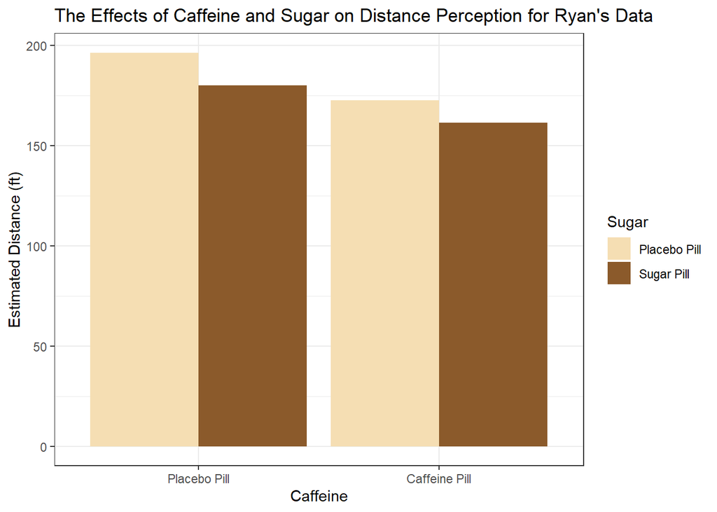

```r
#visualize my data as a bar plot

ggplot(backpack_data, aes(x = caffeine, y = Distance_Est, fill = sugar)) +
  geom_col(position = "dodge") +
  labs(title = "The Effects of Caffeine and Sugar on Distance Perception for Ryan's Data", x = "Caffeine", y = "Estimated Distance (ft)", fill = "Sugar") +
  theme_bw() +
  scale_fill_manual(labels = c("Placebo Pill", "Sugar Pill"), values = c("wheat", "tan4" )) +
  scale_x_discrete("Caffeine", labels = c("Placebo Pill", "Caffeine Pill"))
```

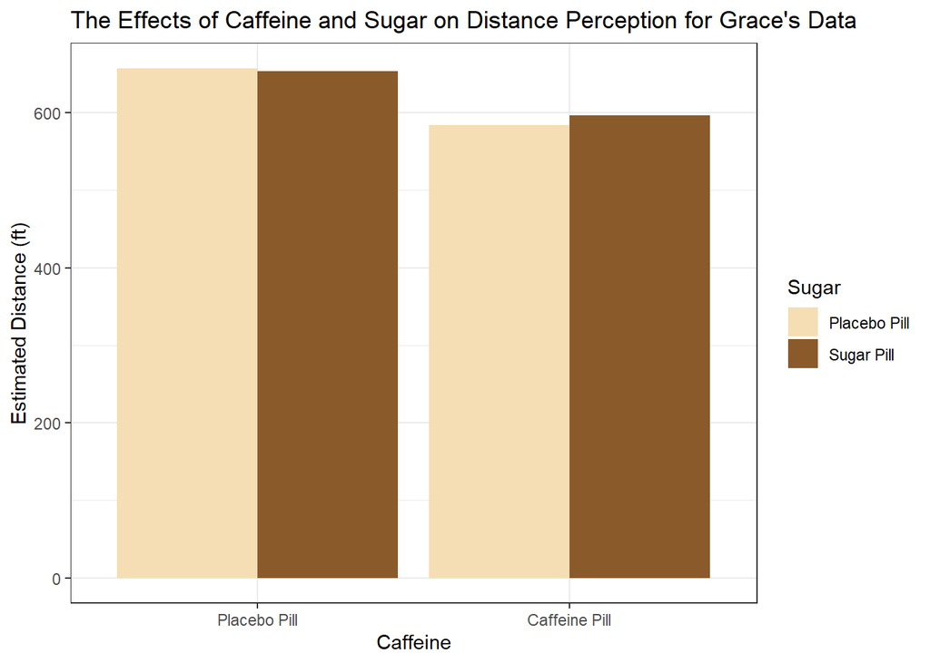

```r
#visualize Grace's data as a bar plot

ggplot(backpack_data_grace, aes(x = caffeine, y = Distance_Est, fill = sugar)) +
  geom_col(position = "dodge") +
  labs(title = "The Effects of Caffeine and Sugar on Distance Perception for Grace's Data", x = "Caffeine", y = "Estimated Distance (ft)", fill = "Sugar") +
  theme_bw() +
  scale_fill_manual(labels = c("Placebo Pill", "Sugar Pill"), values = c("wheat", "tan4" )) +
  scale_x_discrete("Caffeine", labels = c("Placebo Pill", "Caffeine Pill"))
```

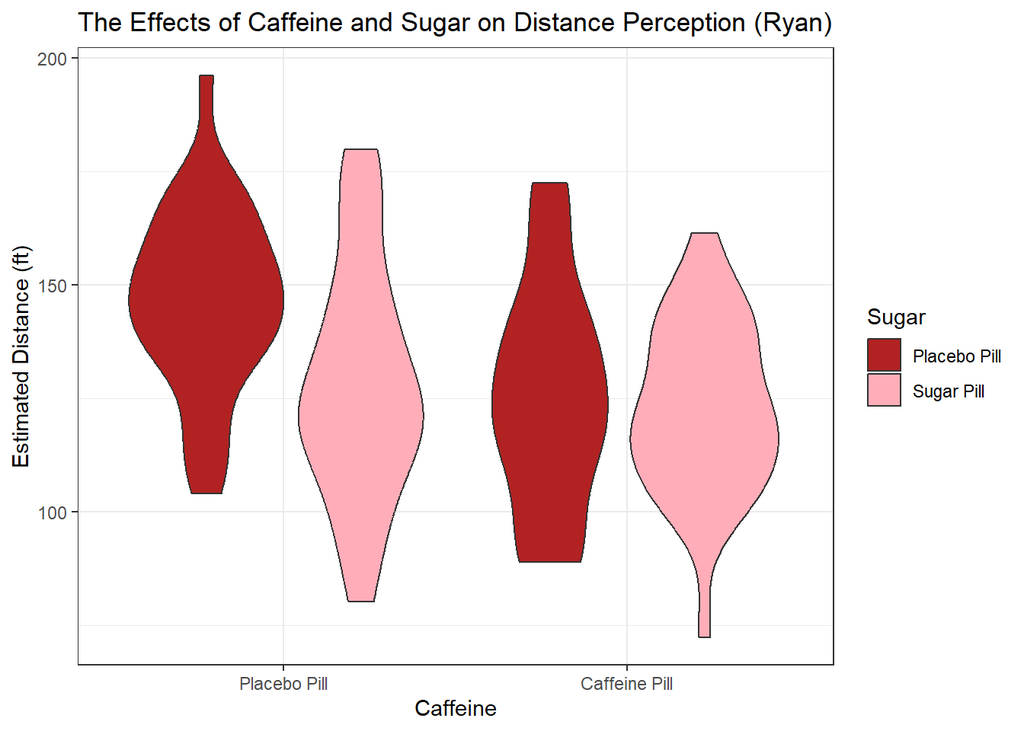

```r
#visualize another way for me

ggplot(backpack_data, aes(x = caffeine, y = Distance_Est, fill = sugar)) +
  geom_violin() +
  labs(title = "The Effects of Caffeine and Sugar on Distance Perception (Ryan)", x  = "Caffeine", y = "Estimated Distance (ft)", fill = "Sugar") +
  theme_bw() +
  scale_fill_manual(labels = c("Placebo Pill", "Sugar Pill"), values = c("firebrick", "lightpink1")) +
  scale_x_discrete("Caffeine", labels = c("Placebo Pill", "Caffeine Pill"))
```

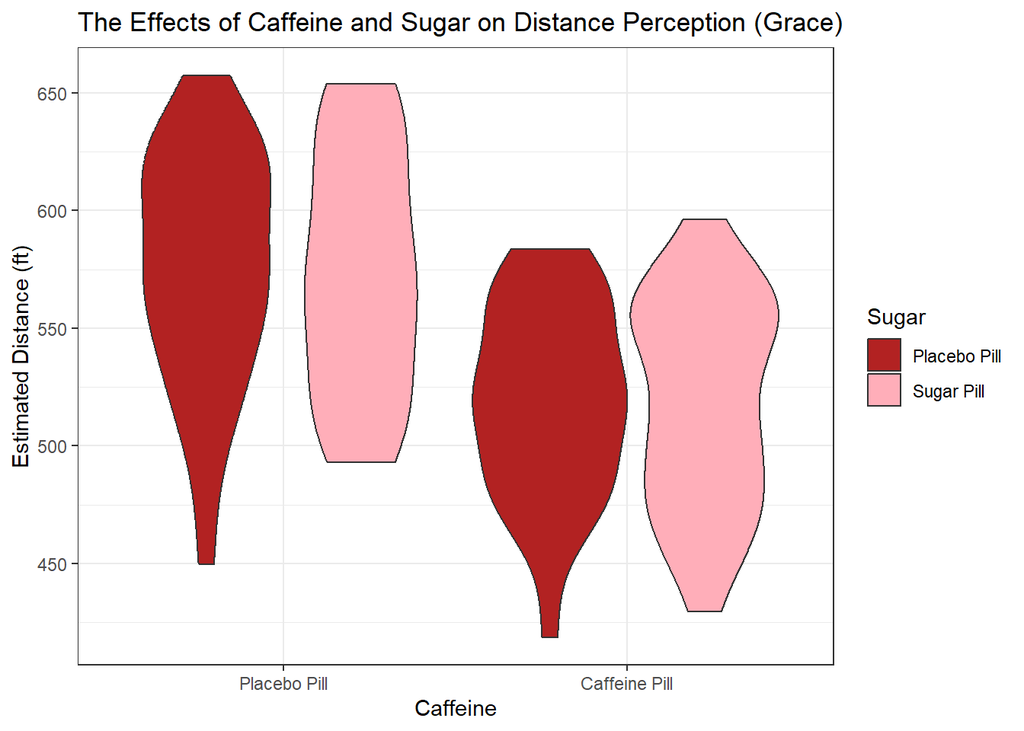

```r
#visualize as violin for Grace

ggplot(backpack_data_grace, aes(x = caffeine, y = Distance_Est, fill = sugar)) +
  geom_violin() +
  labs(title = "The Effects of Caffeine and Sugar on Distance Perception (Grace)", x  = "Caffeine", y = "Estimated Distance (ft)", fill = "Sugar") +
  theme_bw() +
  scale_fill_manual(labels = c("Placebo Pill", "Sugar Pill"), values = c("firebrick", "lightpink1")) +
  scale_x_discrete("Caffeine", labels = c("Placebo Pill", "Caffeine Pill"))
```